# HSC Survey Results

# Scots Bay Survey # 6 Results from 15/07/2024

## Survey Details

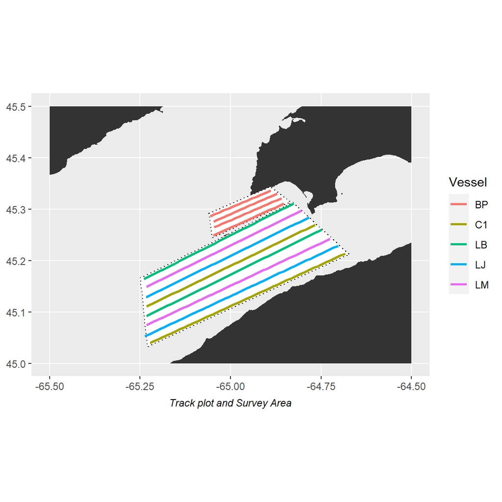

5 commercial purse seiners conducted this fishing survey on 15/07/2024 starting at 20:00:00, which was 0.4 hours after hide tide.

There was no plankton tow or CTD cast conducted.

No tags were applied during this survey.

Samples were obtained for target strength estimation.

### Tides Tables

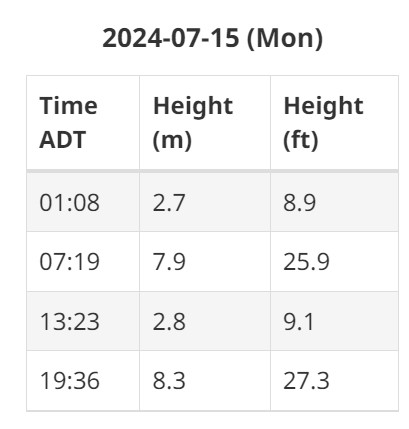

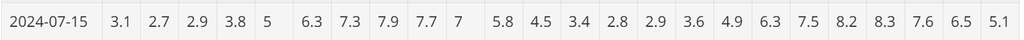

Tide Schedule for Margaretsville NS, Station #315m Source: www.waterlevels.gc.ca

### Acoustic Equipment

Each vessel was equipped with a Simrad ES38-18/200-18C combi (2-in-1) transducer prior to the survey that contains a 38kHz split beam and 200 kHz single beam transducer. Data was logged to the computer hard-drive for post-processing. All participating boats were calibrated on 38kHz before the survey.

## Survey Results

### Main Results

The results are subject to change as DFO will re-evaluate data editing, area estimation and apply a target strength.

**Preliminary biomass prediction for Scots Bay using standardized parallel transects is 4,539mt, and with turnover applied 3,560mt.**

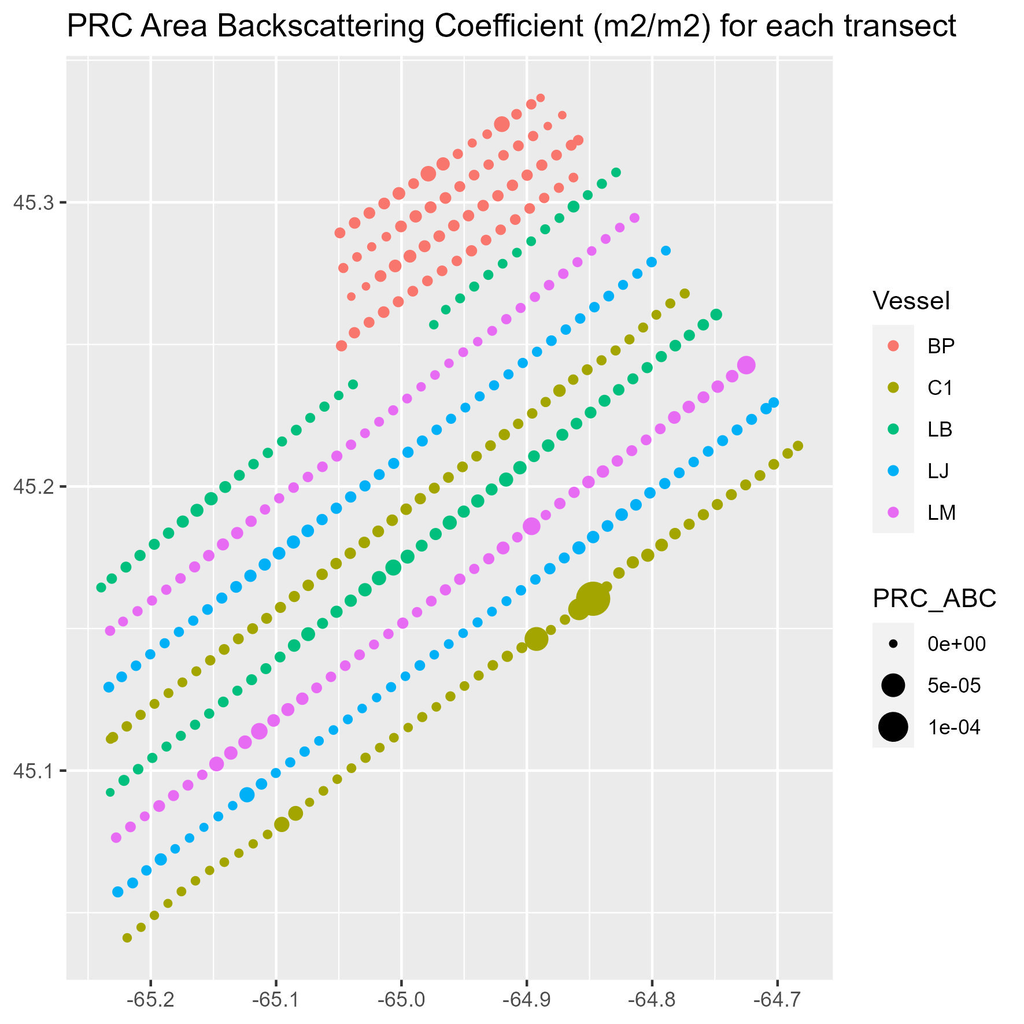

### Transect Details

Table 1: Transect Details

| Vessel | Transect # | Date/Time Start | Date/Time End | Start Lon | Start Lat | End Lon | End Lat | Location | Distance (km) | Speed |
| --- | --- | --- | --- | --- | --- | --- | --- | --- | --- | --- |
| BP | T01 | 2024-07-15 19:34:52 | 2024-07-15 20:32:44 | -65.056 | 45.287 | -64.889 | 45.337 | SB | 14.23 | 7.97 |
| BP | T02 | 2024-07-15 20:41:07 | 2024-07-15 21:28:03 | -64.872 | 45.331 | -65.046 | 45.277 | SB | 14.97 | 10.33 |
| BP | T03 | 2024-07-15 21:32:56 | 2024-07-15 22:28:51 | -65.045 | 45.265 | -64.859 | 45.322 | SB | 15.94 | 9.24 |
| BP | T04 | 2024-07-15 22:37:29 | 2024-07-15 23:25:07 | -64.853 | 45.311 | -65.048 | 45.250 | SB | 16.83 | 11.44 |
| C1 | T01 | 2024-07-15 19:45:19 | 2024-07-15 22:58:51 | -65.223 | 45.040 | -64.684 | 45.214 | SB | 48.10 | 8.05 |
| C1 | T02 | 2024-07-15 23:24:39 | 2024-07-16 02:00:25 | -64.767 | 45.270 | -65.232 | 45.111 | SB | 41.82 | 8.70 |
| LB | T01 | 2024-07-15 19:37:05 | 2024-07-15 22:45:32 | -65.232 | 45.092 | -64.749 | 45.260 | SB | 42.94 | 7.38 |
| LB | T02 | 2024-07-15 23:16:13 | 2024-07-16 01:33:55 | -64.826 | 45.312 | -65.240 | 45.164 | SB | 37.03 | 8.71 |
| LJ | T01 | 2024-07-15 19:43:30 | 2024-07-15 22:54:03 | -65.237 | 45.053 | -64.703 | 45.230 | SB | 46.53 | 7.91 |
| LJ | T02 | 2024-07-15 23:20:14 | 2024-07-16 01:43:38 | -64.783 | 45.285 | -65.233 | 45.129 | SB | 39.39 | 8.90 |
| LM | T01 | 2024-07-15 19:30:27 | 2024-07-15 22:28:33 | -65.232 | 45.075 | -64.725 | 45.243 | SB | 44.44 | 8.08 |
| LM | T02 | 2024-07-15 22:54:52 | 2024-07-16 01:23:54 | -64.804 | 45.298 | -65.232 | 45.149 | SB | 37.77 | 8.21 |

### Survey Summary

Table 2: Acoustic Survey Results

| Vessel | Transect No. | Target Strength (db/kg) | Mean Sa (/m2) | Biomass Density (kg/m2) |
| --- | --- | --- | --- | --- |
| C1 | T01 | -35.5 | -52.184 | 0.021 |
| LM | T01 | -35.5 | -54.869 | 0.012 |
| BP | T01 | -35.5 | -55.175 | 0.011 |
| LB | T01 | -35.5 | -55.542 | 0.010 |
| BP | T03 | -35.5 | -57.213 | 0.007 |
| LJ | T02 | -35.5 | -58.817 | 0.005 |
| LJ | T01 | -35.5 | -58.880 | 0.005 |
| C1 | T02 | -35.5 | -59.417 | 0.004 |
| BP | T02 | -35.5 | -59.461 | 0.004 |
| BP | T04 | -35.5 | -59.530 | 0.004 |
| LB | T02 | -35.5 | -59.791 | 0.004 |
| LM | T02 | -35.5 | -61.100 | 0.003 |

Note:  
Transects are listed from greatest to least backscatter.

Table 3: Survey Summary Table

| Layer | Target Strength | Area (km2) | Mean Sa | Density (kg/m2) | Biomass (tons) | Percent Area | Percent Biomass | Standard Error (tons) | Standard Error (%) |
| --- | --- | --- | --- | --- | --- | --- | --- | --- | --- |
| Main Box | -35.5 | 624 | -57.3969 | 0.0065 | 4,029.3062 | 88.4 | 88.8 | 792.53 | 19.67 |
| Northern Box | -35.5 | 82 | -57.5393 | 0.0064 | 509.8711 | 11.6 | 11.2 | 130.90 | 25.67 |

### Greatest Biomass Densities

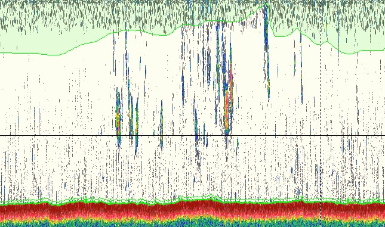

A snip from the transect with the greatest biomass density (kg/m2)

The single point with the largest biomass density (kg/m2) was recorded by **C1**, at the following location:

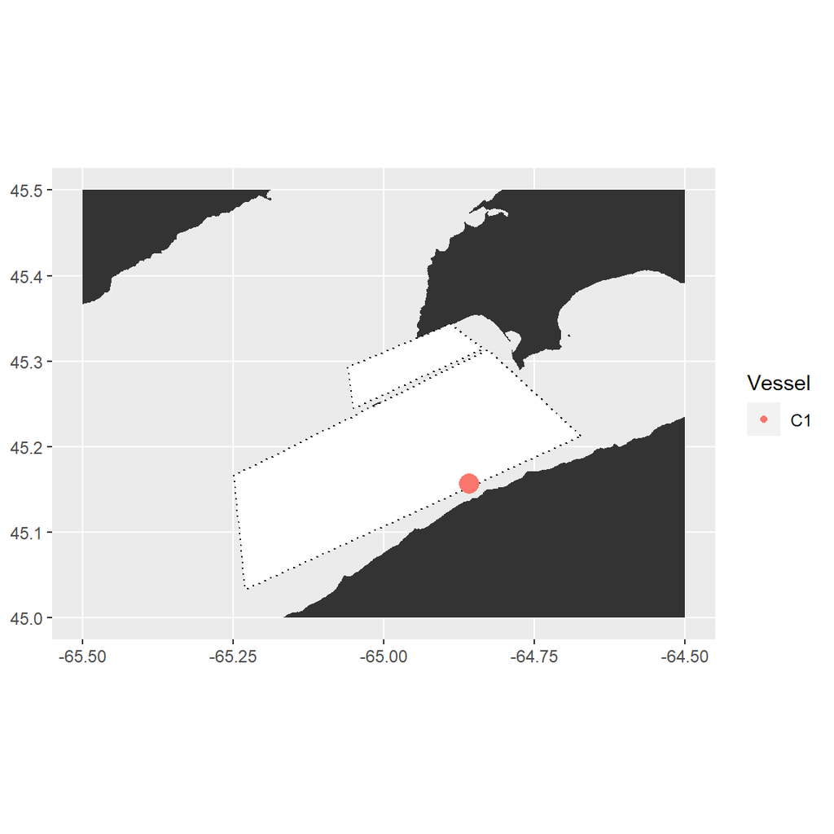

The transect with the greatest average biomass density (kg/m2) was recorded by **C1**, at the following location:

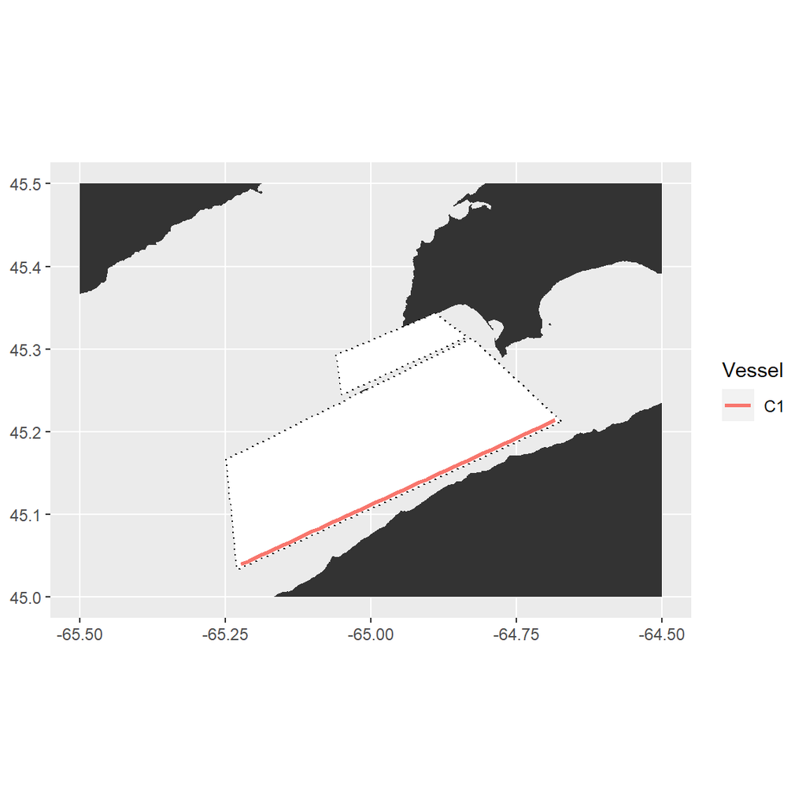

### Annual Summaries

Table 4: Annual Comparison Table

| Ground | Survey Number | Current Year Survey Date | Current Year HSC Estimate | Current Year HSC Turnover Adjusted | Previous Year Survey Date | Previous Year HSC Estimate | Previous Year HSC Turnover Adjusted | Previous Year DFO Estimate | Previous Year DFO Turnover Adjusted |
| --- | --- | --- | --- | --- | --- | --- | --- | --- | --- |
| Scots Bay | 1 | 2024-05-05 | 78,662 | 78,662 | 2023-05-22 | 40,856.000 | 40,856 | 47,629 | 47,629 |
| Scots Bay | 2 | 2024-05-20 | 29,842 | 17,255 | 2023-06-06 | 113,767.329 | 108,783 | 98,582 | 92,772 |
| Scots Bay | 3 | 2024-06-02 | 93,804 | 89,523 | 2023-06-18 | 34,279.387 | 15,158 | 29,417 | 12,720 |
| Scots Bay | 4 | 2024-06-16 | 33,347 | 22,278 | 2023-07-02 | 11,744.776 | 5,113 | 9,330 | 3,622 |
| Scots Bay | 5 | 2024-07-01 | 7,252 | 3,123 | 2023-07-16 | 19,282.634 | 17,575 | 17,387 | 16,022 |
| Scots Bay | 6 | 2024-07-15 | 4,539 | 3,560 | 2023-07-30 | 4,549.933 | 1,904 | 3,474 | 1,093 |
| Scots Bay | 7 | NA | NA | NA | 2023-08-13 | 4,298.806 | 3,616 | 2,777 | 2,247 |
| Scots Bay | 9 | NA | NA | NA | 2023-09-10 | 3,053.669 | 2,916 | 3,219 | 0 |
| Scots Bay | 10 | NA | NA | NA | 2023-09-24 | 3,419.932 | 2,997 | 2,318 | 0 |
| Scots Bay | 8 | NA | NA | NA | 2023-08-27 | 2,896.659 | 2,300 | 1,612 | 1,224 |
| Scots Bay | 11 | NA | NA | NA | 2023-10-09 | 3,387.515 | 2,971 | 2,521 | 0 |

Table 5: Annual Summary Table

| Year | Ground | HSC Estimate | HSC Turnover Adjusted | DFO Estimate | DFO Turnover Adjusted |
| --- | --- | --- | --- | --- | --- |
| 2023 | Scots Bay | 241,536.6 | 204,189 | 218,266 | 177,329 |
| 2024 | Scots Bay | 247,446.0 | 214,401 | NA | NA |

## Plankton, and CTD Data

### Summary map

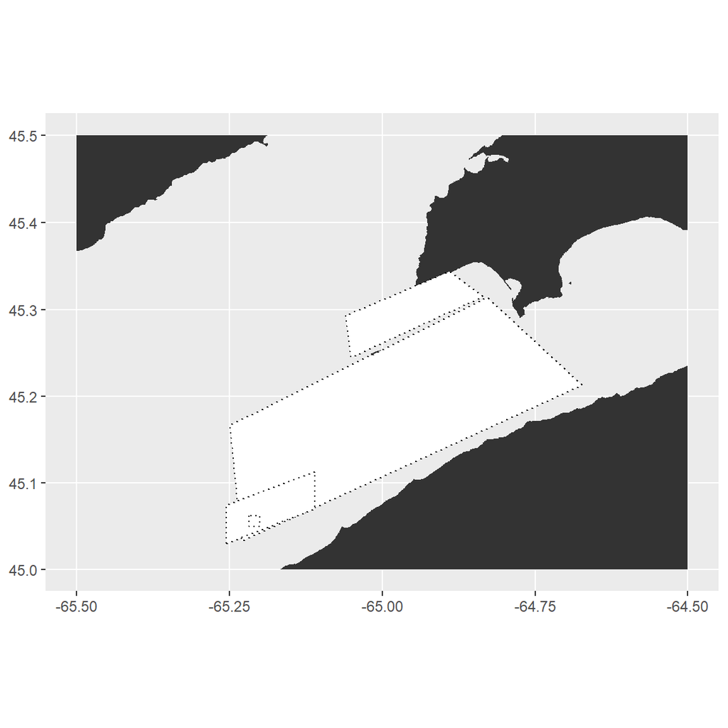

### Plankton Data

#### Tow Summary Table

|  | Tow 1 | Tow 2 |
| --- | --- | --- |
| **Base Details** |  |  |
| Vessel | NA | NA |
| Set Number | NA | NA |
| Ground | SB | SB |
| Date | 15/07/2024 | 15/07/2024 |
| Wind Direction (km/h) | NA | NA |
| Swell (m) | NA | NA |
| Air Temp (c) | NA | NA |
| **Tow Details** |  |  |
| Tow Start | NA | NA |
| Tow End | NA | NA |
| Start Lat | NA | NA |
| End Lat | NA | NA |
| Start Lon | NA | NA |
| End Lon | NA | NA |
| Avg Tow Depth (m) | NA | NA |
| Speed | NA | NA |
| Heading | NA | NA |
| Tide Direction | NA | NA |
| **Other Data Collection** |  |  |
| Flow Start | NA | NA |
| Flow End | NA | NA |
| No. Revolutions | NA | NA |
| Distance (m) | NA | NA |
| Volume | NA | NA |
| Secchi Disappear (m) | NA | NA |
| Secchi Reappear (m) | NA | NA |

#### Tow Depth Profiles

[figure not shown]

Plankton tow depth profile #1

[figure not shown]

Plankton tow depth profile #2

### CTD Data

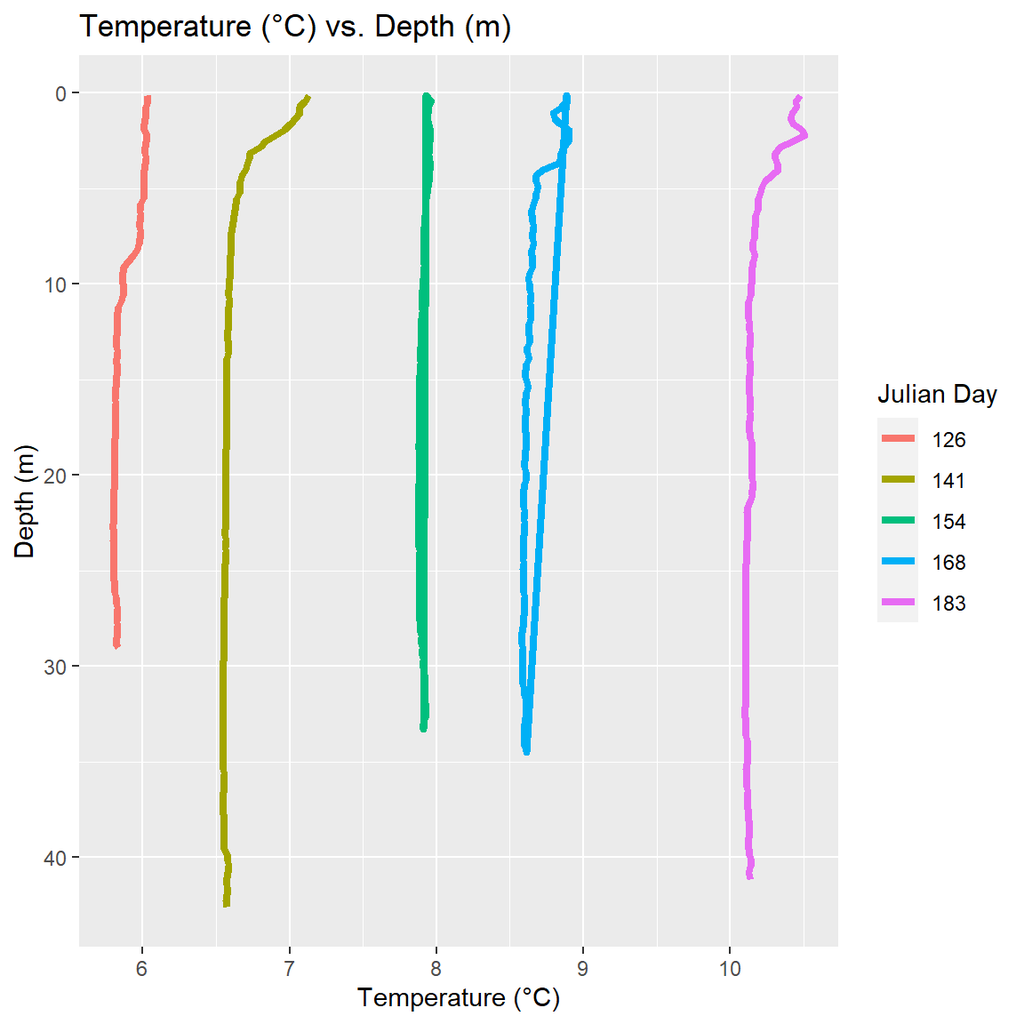

CTD depth profiles for all 2024 Scots Bay surveys so far.

#### Sea surface temperatures

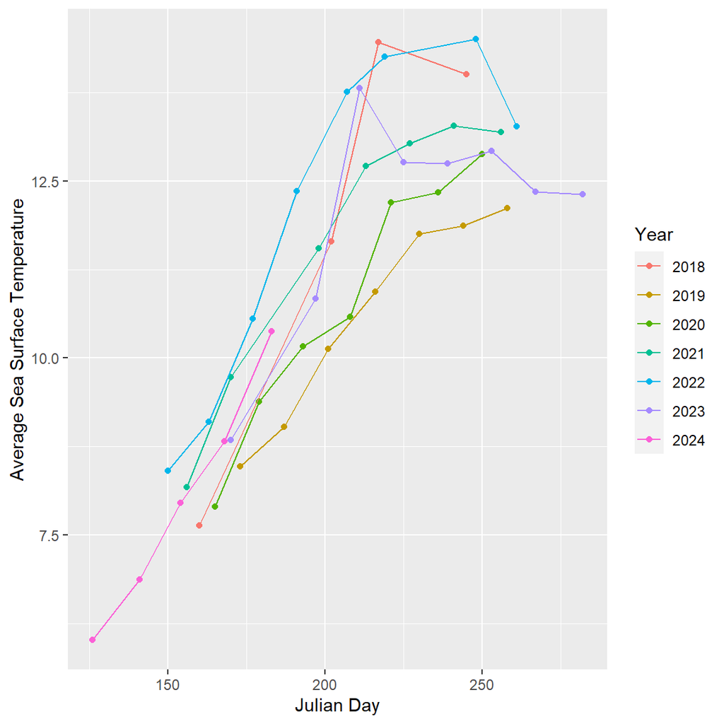

Annual average sea surface temperatures (SST) for Scots Bay.

## Vessel Performance

### Speed

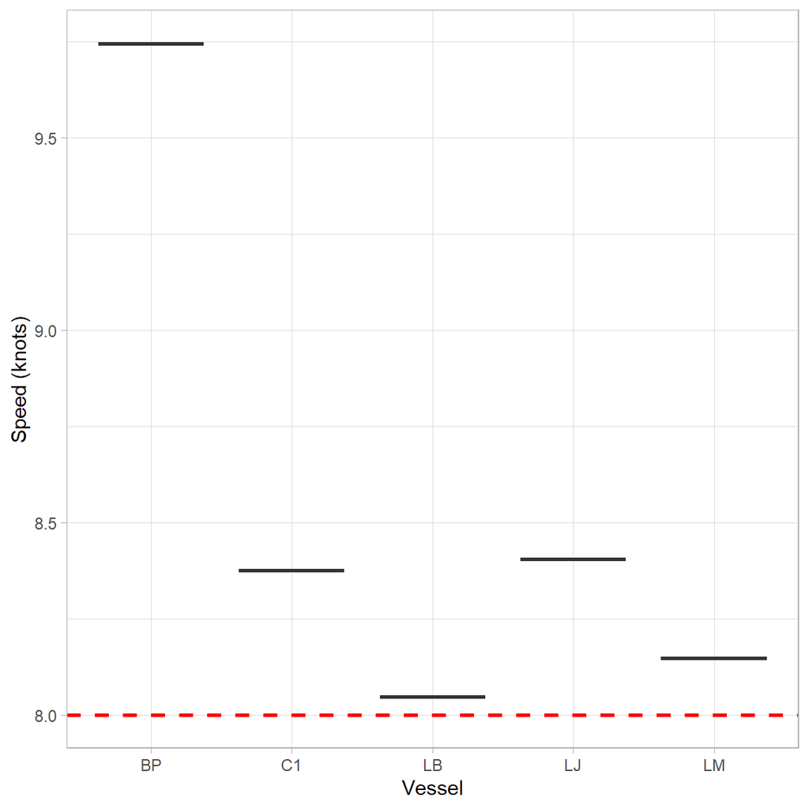

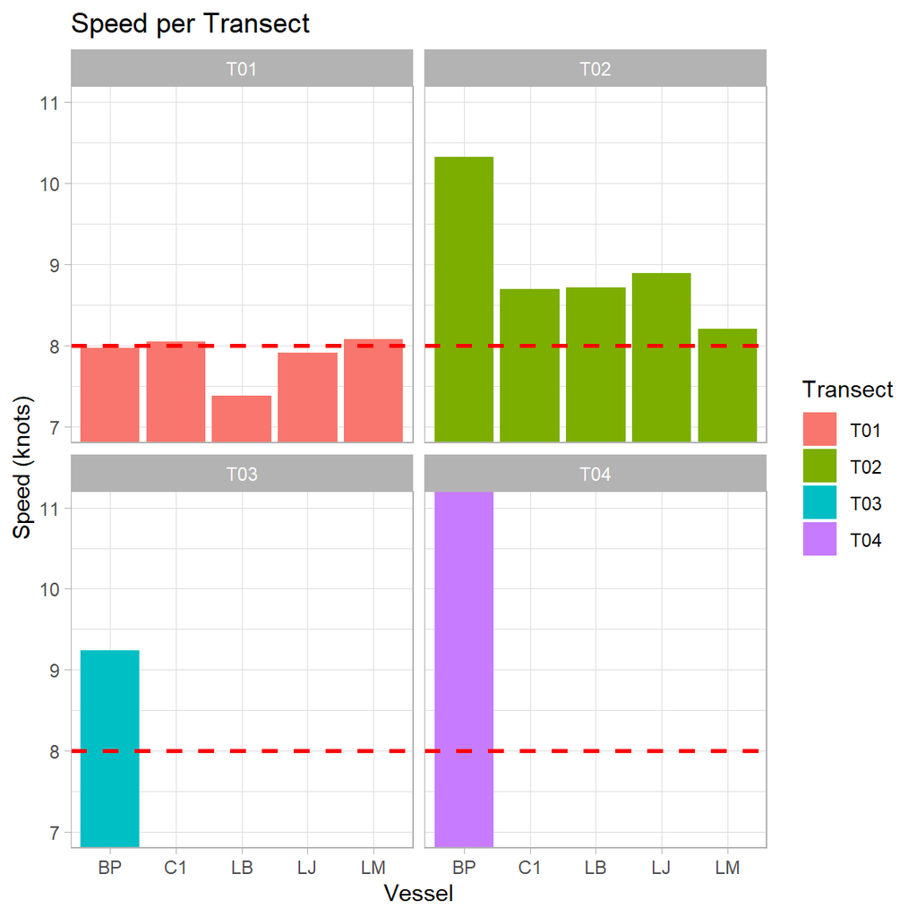

Average vessel speed was 8.54. This is above the 8 knot requirement; vessels are urged to slow down to prevent backscatter noise from interfering with the acoustic data.

### Distance

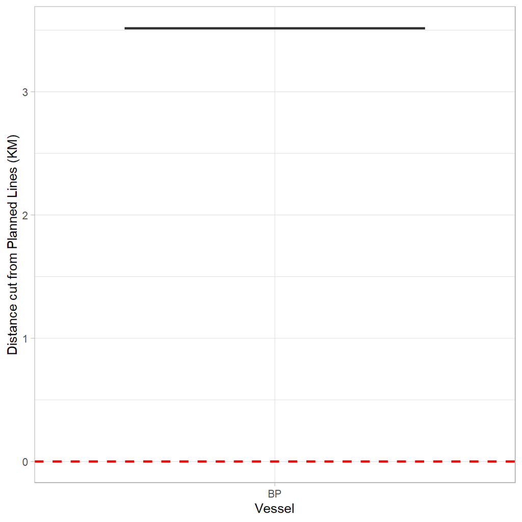

More than 2km of distance was cut from the planned lines; vessels are reminded to complete their assigned lines straight and without deviating or cutting corners short.